[emphasis experiments](https://franciscorichter.github.io/emphasis/experiments/) · validation series · V1

# Complete trees: does the likelihood return the true parameters?

We simulated 40 complete trees (every lineage, the extinct ones included) in each of 64 settings of the ten models, and fitted each tree by its own model, maximising the likelihood directly. There is no Monte Carlo here and nothing hidden: this checks the likelihood itself.

## The answer

- **Intercepts come back.** The speciation intercept is within 10% of its true value in 62 of 64 settings, and the extinction intercept within [0.8, 1.25] in 61 of 64: a complete tree records its extinctions. The exceptions are `k` at +0.35 (0.59 to 0.76).
- **Single covariate slopes come back.** The slopes of D, K and centred or single ED are within 10% in 43 of 50 settings (range 0.86 to 1.20).
- **The diversity slope is too steep.** βN is within 10% in 17 of 30 settings; elsewhere it is 1.10 to 1.39 times its value, mostly at turnover 0.40.
- **Distinctiveness beside N is unstable.** In `ned` its slope ranges from 0.68 to 1.68 times its value.
- **Pooled over each setting’s 40 trees** (one estimate for all of them), 138 of 150 speciation coefficients are within 10% (intercepts on the rate scale, as the rule reads them; 135 on the log scale, as the methods paper reads them). Much of the per-tree scatter is therefore the small size of one tree. Of the 12 left, 7 are βN, off by 14–21%: too steep in five settings at turnover 0.40, too shallow in two.

The registered rule, which asks every coefficient of a setting to be within 10% *and* its bootstrap interval to contain the true value *and* the slope sign to be right on 95% of trees, holds in **29 of 64** settings.

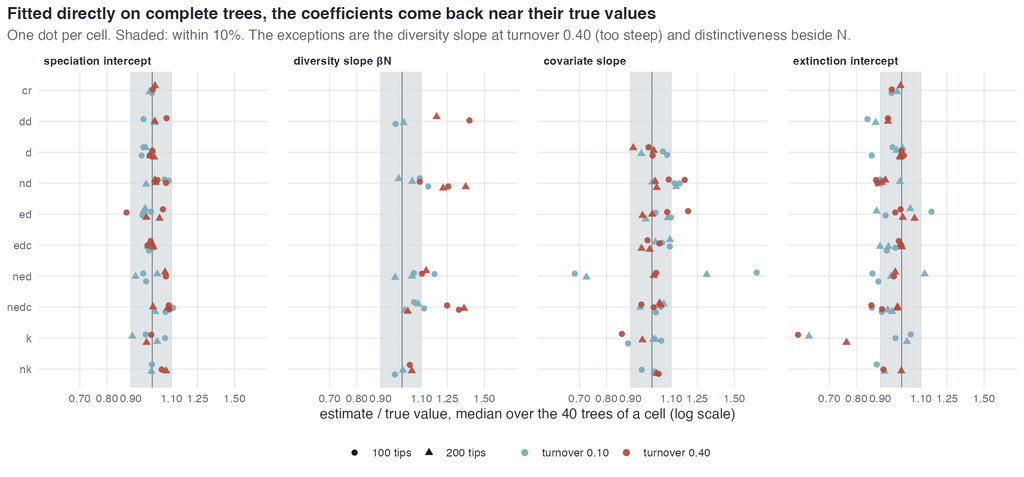

## Design

| models | all ten, exponential link |
| --- | --- |
| settings | 100 and 200 tips, turnover 0.10 and 0.40; lineage-level effect ±0.35 on speciation, extinction constant; 64 reachable settings |
| trees | 40 a setting, complete, crown age 15, both crown lineages surviving: 2560 trees |
| fit | the complete-data log-likelihood, maximised by Subplex from the true values and a perturbed start |
| build | emphasis 1.0.0.9000 (`182055b`), 31 October 2026 |

## The rule, setting by setting

Grey settings fail; the label says which coefficient and which part of the rule. Most failures are of the interval or of βN.

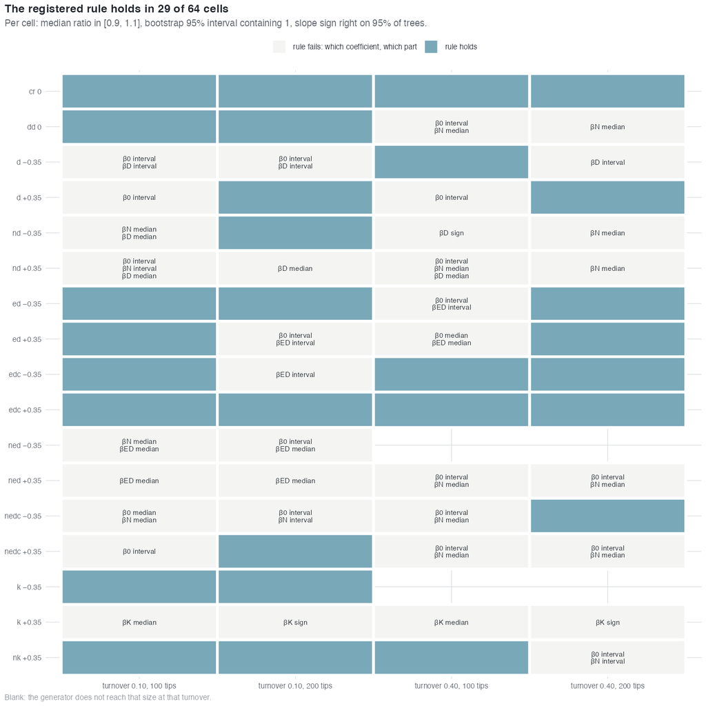

**Every tree: the spread behind each median**

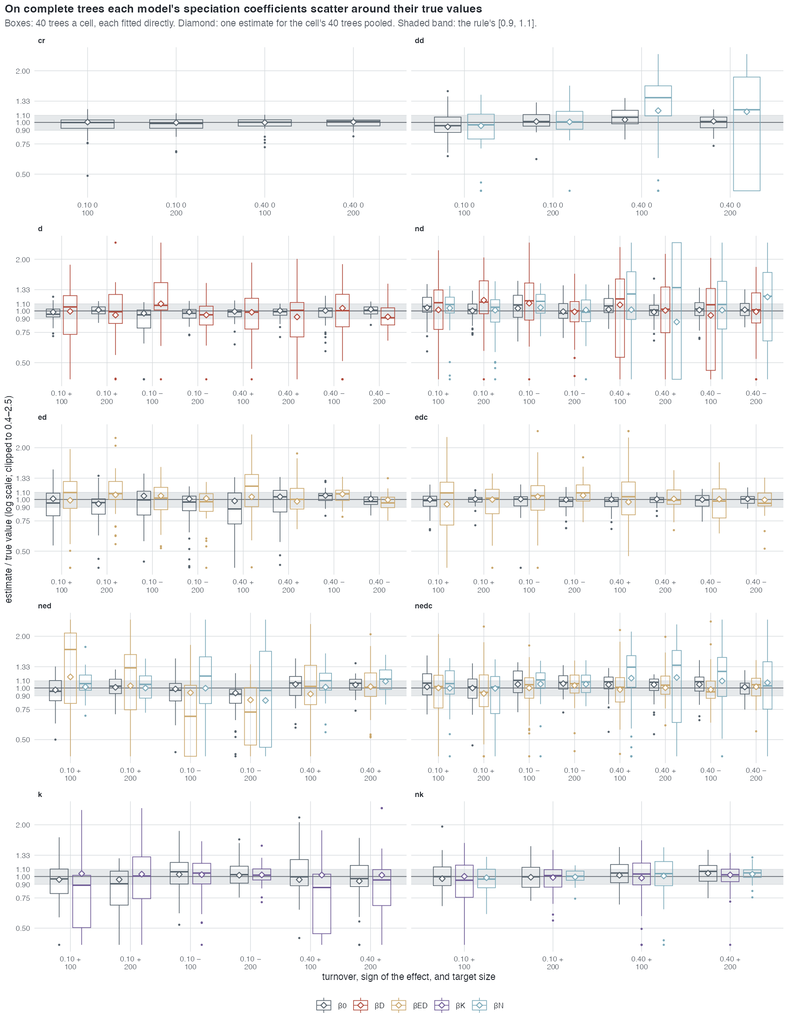

**Extinction intercept, tree by tree**

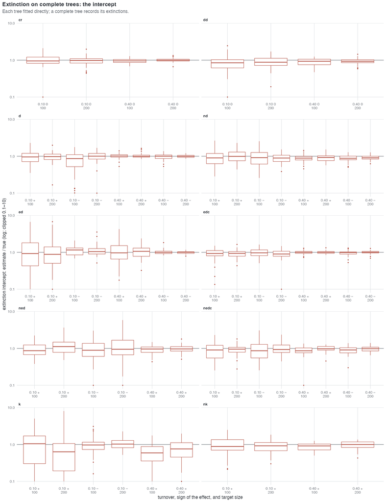

**Table: every speciation coefficient, setting by setting**

Median ratio of estimate to true value over the 40 trees, with its bootstrap 95% interval below. outside [0.9, 1.1] within, but the interval excludes 1 or the sign is wrong on more than 5% of trees meets the rule

| model | effect | coefficient | turnover 0.10 100 tips | turnover 0.10 200 tips | turnover 0.40 100 tips | turnover 0.40 200 tips |
| --- | --- | --- | --- | --- | --- | --- |
| `cr` | none | β0 | **1.00** 0.97–1.02 | **0.99** 0.94–1.02 | **1.00** 0.98–1.02 | **1.01** 0.96–1.03 |
| `dd` | none | β0 | **0.96** 0.90–1.02 | **1.01** 0.96–1.08 | **1.07** 1.02–1.12 interval excludes 1 | **1.01** 0.96–1.05 |
|  | none | βN | **0.97** 0.90–1.05 | **1.01** 0.95–1.11 | **1.39** 1.27–1.55 interval excludes 1 | **1.19** 0.62–1.70 |
| `d` | −0.35 | β0 | **0.95** 0.87–0.98 interval excludes 1 | **0.97** 0.94–0.99 interval excludes 1 | **1.00** 0.95–1.03 | **1.01** 0.98–1.05 |
|  | −0.35 | βD | **1.08** 1.04–1.27 interval excludes 1 | **0.95** 0.87–1.00 interval excludes 1 | **1.00** 0.87–1.19 | **0.91** 0.87–0.98 interval excludes 1 |
|  | +0.35 | β0 | **0.96** 0.94–0.99 interval excludes 1 | **1.00** 0.98–1.03 | **0.99** 0.96–1.00 interval excludes 1 | **0.99** 0.97–1.01 |
|  | +0.35 | βD | **1.06** 0.92–1.16 | **0.99** 0.88–1.13 | **0.98** 0.85–1.04 | **1.01** 0.86–1.06 |
| `nd` | −0.35 | β0 | **1.08** 0.97–1.14 | **0.97** 0.93–1.02 | **1.03** 0.98–1.08 | **1.02** 0.97–1.07 |
|  | −0.35 | βN | **1.14** 1.02–1.21 interval excludes 1 | **0.98** 0.91–1.04 | **1.09** 0.86–1.38 | **1.22** 0.80–1.56 |
|  | −0.35 | βD | **1.15** 0.94–1.27 | **1.00** 0.92–1.09 | **1.09** 0.64–1.23 sign right 92% | **1.02** 0.92–1.13 |
|  | +0.35 | β0 | **1.06** 1.03–1.14 interval excludes 1 | **1.02** 0.99–1.07 | **1.07** 1.00–1.14 interval excludes 1 | **1.01** 0.98–1.05 |
|  | +0.35 | βN | **1.09** 1.02–1.15 interval excludes 1 | **1.05** 0.95–1.11 | **1.26** 1.11–1.49 interval excludes 1 | **1.37** 0.84–2.46 |
|  | +0.35 | βD | **1.12** 0.90–1.22 | **1.13** 1.02–1.35 interval excludes 1 | **1.18** 0.91–1.33 | **1.02** 0.89–1.17 |
| `ed` | −0.35 | β0 | **0.99** 0.96–1.05 | **0.97** 0.89–1.01 | **1.05** 1.02–1.07 interval excludes 1 | **0.97** 0.95–1.00 |
|  | −0.35 | βED | **1.02** 0.96–1.10 | **0.97** 0.90–1.02 | **1.08** 1.02–1.12 interval excludes 1 | **0.95** 0.94–1.01 |
|  | +0.35 | β0 | **0.95** 0.85–1.00 | **0.96** 0.86–0.98 interval excludes 1 | **0.88** 0.78–0.97 interval excludes 1 | **1.04** 0.97–1.09 |
|  | +0.35 | βED | **1.10** 0.96–1.22 | **1.08** 1.01–1.16 interval excludes 1 | **1.20** 1.03–1.31 interval excludes 1 | **1.00** 0.91–1.05 |
| `edc` | −0.35 | β0 | **1.00** 0.96–1.02 | **0.98** 0.94–1.02 | **0.99** 0.93–1.03 | **1.01** 0.96–1.03 |
|  | −0.35 | βED | **1.05** 0.99–1.14 | **1.09** 1.05–1.13 interval excludes 1 | **0.98** 0.91–1.09 | **0.95** 0.94–1.06 |
|  | +0.35 | β0 | **0.98** 0.96–1.00 | **1.00** 0.98–1.02 | **0.98** 0.94–1.02 | **1.00** 0.98–1.02 |
|  | +0.35 | βED | **1.09** 0.90–1.20 | **1.02** 0.91–1.07 | **1.04** 0.90–1.16 | **0.99** 0.95–1.07 |
| `ned` | −0.35 | β0 | **0.97** 0.89–1.03 | **0.92** 0.86–0.95 interval excludes 1 | not reached | not reached |
|  | −0.35 | βN | **1.17** 0.97–1.39 | **0.97** 0.58–1.30 | not reached | not reached |
|  | −0.35 | βED | **0.68** 0.52–0.91 interval excludes 1, sign right 82% | **0.72** 0.56–0.83 interval excludes 1, sign right 92% | not reached | not reached |
|  | +0.35 | β0 | **0.96** 0.87–1.06 | **1.02** 0.96–1.07 | **1.07** 1.01–1.13 interval excludes 1 | **1.06** 1.03–1.10 interval excludes 1 |
|  | +0.35 | βN | **1.06** 1.00–1.14 | **1.05** 0.96–1.15 | **1.10** 1.03–1.16 interval excludes 1 | **1.13** 1.03–1.22 interval excludes 1 |
|  | +0.35 | βED | **1.68** 1.01–1.96 interval excludes 1, sign right 92% | **1.31** 0.91–1.48 | **1.02** 0.88–1.25 | **1.01** 0.97–1.15 |
| `nedc` | −0.35 | β0 | **1.11** 1.04–1.20 interval excludes 1 | **1.08** 1.02–1.15 interval excludes 1 | **1.09** 1.05–1.13 interval excludes 1 | **1.00** 0.97–1.05 |
|  | −0.35 | βN | **1.11** 1.05–1.16 interval excludes 1 | **1.08** 1.01–1.14 interval excludes 1 | **1.25** 0.99–1.41 | **1.03** 0.91–1.28 |
|  | −0.35 | βED | **1.05** 0.94–1.13 | **1.06** 0.98–1.14 | **0.95** 0.89–1.05 | **1.04** 0.95–1.11 |
|  | +0.35 | β0 | **1.07** 1.01–1.18 interval excludes 1 | **1.01** 0.92–1.06 | **1.09** 1.03–1.14 interval excludes 1 | **1.08** 1.01–1.11 interval excludes 1 |
|  | +0.35 | βN | **1.06** 1.00–1.15 | **1.01** 0.89–1.11 | **1.32** 1.13–1.47 interval excludes 1 | **1.36** 1.01–1.51 interval excludes 1 |
|  | +0.35 | βED | **1.02** 0.91–1.14 | **0.94** 0.82–1.06 | **1.01** 0.88–1.08 | **1.04** 0.98–1.09 |
| `k` | −0.35 | β0 | **1.07** 0.96–1.13 | **1.02** 0.94–1.10 | not reached | not reached |
|  | −0.35 | βK | **1.05** 0.95–1.15 | **1.02** 0.97–1.08 | not reached | not reached |
|  | +0.35 | β0 | **0.97** 0.90–1.05 | **0.91** 0.81–1.02 | **1.00** 0.92–1.11 | **0.97** 0.88–1.07 |
|  | +0.35 | βK | **0.89** 0.67–0.99 interval excludes 1, sign right 85% | **1.01** 0.91–1.13 sign right 92% | **0.86** 0.63–0.98 interval excludes 1, sign right 78% | **0.95** 0.80–1.06 sign right 92% |
| `nk` | +0.35 | β0 | **1.00** 0.94–1.09 | **1.00** 0.95–1.07 | **1.05** 0.97–1.14 | **1.07** 1.01–1.14 interval excludes 1 |
|  | +0.35 | βN | **0.97** 0.92–1.06 | **1.00** 0.97–1.05 | **1.04** 0.97–1.14 | **1.05** 1.02–1.07 interval excludes 1 |
|  | +0.35 | βK | **0.95** 0.84–1.06 | **1.01** 0.94–1.06 | **1.03** 0.92–1.13 | **1.02** 0.97–1.06 |

**Table: the extinction coefficients, setting by setting**

γ0: the extinction intercept as estimate / true value, outside [0.8, 1.25]. The extinction slopes were generated at 0, so their estimate is shown as it is, when the 10th–90th percentile excludes 0. Below each median: the 10th to 90th percentile over the 40 trees.

| model | effect | coefficient | turnover 0.10 100 tips | turnover 0.10 200 tips | turnover 0.40 100 tips | turnover 0.40 200 tips |
| --- | --- | --- | --- | --- | --- | --- |
| `cr` | none | γ0 (ratio) | **0.95** 0.73 to 1.33 | **0.98** 0.76 to 1.20 | **0.95** 0.84 to 1.13 | **0.99** 0.89 to 1.09 |
| `dd` | none | γ0 (ratio) | **0.84** 0.45 to 1.32 | **0.88** 0.61 to 1.36 | **0.93** 0.59 to 1.16 | **0.93** 0.65 to 1.11 |
|  | none | γN | **0.003** -0.004 to 0.014 | **0.001** -0.002 to 0.004 | **0.002** -0.002 to 0.013 | **0.001** -0.001 to 0.004 |
| `d` | −0.35 | γ0 (ratio) | **0.86** 0.22 to 1.39 | **1.00** 0.66 to 1.33 | **1.00** 0.74 to 1.12 | **0.99** 0.90 to 1.09 |
|  | −0.35 | γD | **-0.078** -0.835 to 0.125 | **-0.014** -0.142 to 0.153 | **0.002** -0.150 to 0.087 | **-0.003** -0.078 to 0.122 |
|  | +0.35 | γ0 (ratio) | **0.96** 0.48 to 1.49 | **0.98** 0.65 to 1.26 | **1.01** 0.87 to 1.18 | **0.99** 0.90 to 1.22 |
|  | +0.35 | γD | **0.040** -0.298 to 0.223 | **-0.029** -0.291 to 0.164 | **-0.011** -0.162 to 0.186 | **-0.000** -0.184 to 0.225 |
| `nd` | −0.35 | γ0 (ratio) | **0.92** 0.47 to 1.73 | **0.89** 0.62 to 1.36 | **0.88** 0.62 to 1.14 | **0.91** 0.71 to 1.13 |
|  | −0.35 | γN | **0.001** -0.009 to 0.009 | **0.001** -0.002 to 0.005 | **0.002** -0.001 to 0.008 | **0.001** -0.001 to 0.005 |
|  | −0.35 | γD | **-0.005** -0.109 to 0.106 | **-0.036** -0.165 to 0.084 | **-0.017** -0.098 to 0.092 | **-0.021** -0.095 to 0.099 |
|  | +0.35 | γ0 (ratio) | **0.90** 0.51 to 1.90 | **0.99** 0.58 to 1.56 | **0.89** 0.64 to 1.19 | **0.92** 0.70 to 1.13 |
|  | +0.35 | γN | **0.001** -0.008 to 0.010 | **-0.000** -0.005 to 0.004 | **0.001** -0.006 to 0.007 | **0.001** -0.002 to 0.010 |
|  | +0.35 | γD | **-0.000** -0.136 to 0.147 | **0.027** -0.137 to 0.107 | **-0.014** -0.153 to 0.133 | **0.013** -0.221 to 0.106 |
| `ed` | −0.35 | γ0 (ratio) | **1.16** 0.77 to 1.53 | **1.04** 0.79 to 1.62 | **0.99** 0.90 to 1.13 | **1.01** 0.89 to 1.07 |
|  | −0.35 | γED | **-0.042** -0.131 to 0.081 | **0.005** -0.101 to 0.064 | **-0.006** -0.051 to 0.038 | **0.004** -0.029 to 0.038 |
|  | +0.35 | γ0 (ratio) | **0.92** 0.19 to 3.97 | **0.88** 0.38 to 4.46 | **0.97** 0.52 to 2.42 | **1.07** 0.60 to 1.62 |
|  | +0.35 | γED | **-0.023** -0.512 to 0.352 | **0.063** -0.461 to 0.402 | **0.003** -0.314 to 0.196 | **-0.033** -0.185 to 0.156 |
| `edc` | −0.35 | γ0 (ratio) | **0.97** 0.70 to 1.49 | **0.90** 0.65 to 1.24 | **0.99** 0.77 to 1.24 | **1.00** 0.89 to 1.09 |
|  | −0.35 | γED | **0.010** -0.244 to 0.156 | **-0.025** -0.200 to 0.164 | **0.006** -0.102 to 0.069 | **-0.023** -0.074 to 0.069 |
|  | +0.35 | γ0 (ratio) | **0.93** 0.56 to 1.34 | **0.94** 0.64 to 1.23 | **1.00** 0.85 to 1.14 | **1.00** 0.91 to 1.12 |
|  | +0.35 | γED | **0.031** -0.401 to 0.397 | **-0.018** -0.353 to 0.157 | **-0.032** -0.177 to 0.136 | **-0.007** -0.158 to 0.122 |
| `ned` | −0.35 | γ0 (ratio) | **0.89** 0.38 to 1.98 | **0.95** 0.49 to 3.27 | not reached | not reached |
|  | −0.35 | γN | **0.004** -0.007 to 0.016 | **-0.000** -0.015 to 0.010 | not reached | not reached |
|  | −0.35 | γED | **-0.005** -0.228 to 0.134 | **0.004** -0.341 to 0.147 | not reached | not reached |
|  | +0.35 | γ0 (ratio) | **0.87** 0.53 to 1.40 | **1.12** 0.57 to 2.29 | **0.96** 0.67 to 1.25 | **0.97** 0.68 to 1.23 |
|  | +0.35 | γN | **0.001** -0.008 to 0.011 | **-0.001** -0.005 to 0.005 | **0.001** -0.002 to 0.005 | **0.000** -0.002 to 0.002 |
|  | +0.35 | γED | **0.007** -0.201 to 0.167 | **-0.056** -0.223 to 0.125 | **-0.003** -0.101 to 0.050 | **-0.005** -0.084 to 0.081 |
| `nedc` | −0.35 | γ0 (ratio) | **0.86** 0.38 to 1.95 | **0.93** 0.64 to 1.34 | **0.91** 0.66 to 1.18 | **0.98** 0.77 to 1.14 |
|  | −0.35 | γN | **0.001** -0.009 to 0.013 | **-0.000** -0.003 to 0.003 | **0.001** -0.003 to 0.008 | **-0.000** -0.003 to 0.003 |
|  | −0.35 | γED | **-0.005** -0.170 to 0.091 | **-0.003** -0.127 to 0.075 | **-0.019** -0.123 to 0.053 | **-0.021** -0.095 to 0.044 |
|  | +0.35 | γ0 (ratio) | **0.91** 0.44 to 1.48 | **0.95** 0.55 to 1.40 | **0.86** 0.68 to 1.14 | **0.98** 0.75 to 1.21 |
|  | +0.35 | γN | **0.000** -0.005 to 0.011 | **0.000** -0.002 to 0.005 | **0.001** -0.003 to 0.007 | **0.000** -0.003 to 0.002 |
|  | +0.35 | γED | **-0.026** -0.185 to 0.178 | **0.055** -0.162 to 0.176 | **0.010** -0.151 to 0.071 | **-0.038** -0.204 to 0.054 |
| `k` | −0.35 | γ0 (ratio) | **0.97** 0.48 to 1.94 | **1.03** 0.55 to 1.57 | not reached | not reached |
|  | −0.35 | γK | **0.011** -0.085 to 0.131 | **0.002** -0.051 to 0.068 | not reached | not reached |
|  | +0.35 | γ0 (ratio) | **1.05** 0.00 to 2.15 | **0.63** 0.00 to 2.11 | **0.59** 0.27 to 1.07 | **0.76** 0.35 to 1.44 |
|  | +0.35 | γK | **0.046** -0.395 to 1.427 | **0.016** -0.655 to 0.574 | **0.092** -0.036 to 0.455 | **0.008** -0.091 to 0.291 |
| `nk` | +0.35 | γ0 (ratio) | **0.88** 0.35 to 1.79 | **0.92** 0.56 to 1.27 | **0.91** 0.58 to 1.14 | **1.00** 0.71 to 1.23 |
|  | +0.35 | γN | **0.001** -0.009 to 0.010 | **0.001** -0.002 to 0.004 | **0.001** -0.005 to 0.007 | **0.000** -0.002 to 0.002 |
|  | +0.35 | γK | **0.006** -0.058 to 0.077 | **0.001** -0.031 to 0.034 | **0.004** -0.024 to 0.042 | **0.001** -0.021 to 0.029 |

Built by `report/V1-report.R` of the study repository from `results/V1/jobs` (per-tree rows), `sim/V1-analysis.R` and `sim/V1-pooled.R`. The pooled estimate was added after the registered rule was evaluated.